# CS 5324 Lab 7: Recurrent Neural Network

## Graduate Analysis: Concept Net

✅ Research and use the ConceptNet, Numberbatch embedding and compare to GloVe. Which method is better for your specific application?

The code section below defines the size of embedding and loads a pre-trained embedding file named 'numberbatch-en-17.04b.txt'. Then, it reads the text file into memory and assigns the glove data to a dictionary named 'embeddings_index', where the keys are the words and the values are the corresponding vectors. The code then prints the number of word vectors in the embedding file.

Next, the code initializes an embedding matrix of shape (len(word_index) + 1, EMBED_SIZE) with zeros. The variable 'found_words' counts the number of words that were found in the pre-trained embedding file. The code loops through each word in the 'word_index' and assigns its corresponding vector from 'embeddings_index' to the 'embedding_matrix'. If the word is not found in the 'embeddings_index', it is assigned an all-zeros vector.

Finally, the code prints the shape of the embedding matrix, the total words found, and the percentage of words found in the pre-trained embedding file.

```python
# Defines the embedding size
EMBED_SIZE = 300
```

```python
# Defines name of glove text file.
glove_file = "numberbatch-en-17.04b.txt"

# Reads the glove file into memory.
with open(glove_file, "r", encoding="utf-8") as file:
    glove_data = file.readlines()
```

```python
# Assigning embedding index
embeddings_index = {}

# Assigns glove data to embeddings dictionary.
for i, line in enumerate(glove_data):
    values = line.split()
    if values:
        word = values[0]
        coefs = np.asarray(values[1:], dtype="float32")
        embeddings_index[word] = coefs

# Prints the number of word vectors.
print("Found %s word vectors." % len(embeddings_index))
```

```
Found 418082 word vectors.
```

```python
# Fills in the matrix using the ordering from the keras
# word tokenizer that was implemented previously.
found_words = 0
embedding_matrix = np.zeros((len(word_index) + 1, EMBED_SIZE))
for word, i in word_index.items():
    embedding_vector = embeddings_index.get(word)
    if embedding_vector is not None:
        # words not found in embedding index will be ALL-ZEROS
        embedding_matrix[i] = embedding_vector
        found_words = found_words + 1
```

```python
# Prints the data for the found words and embedding matrix.
print(f"""\
Embedding Shape: {embedding_matrix.shape}
Total Words Found: {found_words}
Percentage: {found_words / embedding_matrix.shape[0] * 100:.3f}
""")
```

```
Embedding Shape: (34105, 300)
Total Words Found: 32922
Percentage: 96.531
```

```python
# Saves the embedding layer
embedding_layer = Embedding(
    len(word_index) + 1,
    EMBED_SIZE,
    weights=[embedding_matrix],
    input_length=MAX_ART_LEN,
    trainable=False,
)
```

```python
rnnB = Sequential()
rnnB.add(embedding_layer)
rnnB.add(LSTM(100, dropout=0.2, recurrent_dropout=0.2))
rnnB.add(Dense(NUM_CLASSES, activation="sigmoid"))
rnnB.compile(
    optimizer="Adamax",
    loss="mse",
    metrics=[keras.metrics.Recall(), keras.metrics.AUC()],
)

rnnB_history = rnnB.fit(
    X_train,
    y_train_ohe,
    validation_data=(X_test, y_test_ohe),
    epochs=EPOCHS,
    batch_size=128,
)
clear_screen()

rnnB.summary()
```

```
Model: "sequential_8"
_________________________________________________________________
 Layer (type)                Output Shape              Param #
=================================================================
 embedding_4 (Embedding)     (None, 1000, 300)         10231500

 lstm_7 (LSTM)               (None, 100)               160400

 dense_8 (Dense)             (None, 2)                 202

=================================================================
Total params: 10,392,102
Trainable params: 160,602
Non-trainable params: 10,231,500
_________________________________________________________________
```

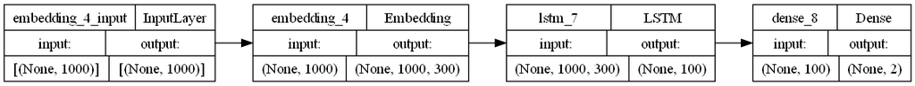

```python
# you will need to install pydot properly on your machine to get this running
plot_model(
    rnnB,
    to_file="model.png",
    show_shapes=True,
    show_layer_names=True,
    rankdir="LR",
    expand_nested=False,
    dpi=96,
)
```

Below, we generate predictions using RNNB and print the classification report based on the actual test data and predicted data. The y_predict_proba array contains the predicted probabilities for each class, while the y_predict array is the binary predicted output by rounding off these probabilities.

The classification_report() function from scikit-learn is then used to print the precision, recall, and F1-score for both classes (0 and 1), as well as micro, macro, weighted, and samples average scores for the model's overall performance.

In this case, the model achieves an average score of 0.84 for both classes in the precision, recall, and F-1 score evaluation methods.

```python
# history1 = []

# history1.append( tmp )
# yhat_probaB = rnnB.predict(X_test) # sigmoid output probabilities
# yhatB = np.round(yhat_probaB) # round to get binary class

# Defines the y-prediction probability and y-prediction arrays
y_predict_proba = rnnB.predict(X_test)
y_predict = np.round(y_predict_proba)

clear_screen()

# Prints classification report
print(classification_report(y_test_ohe, y_predict, zero_division=0))
```

```
              precision    recall  f1-score   support

           0       0.84      0.84      0.84       996
           1       0.84      0.84      0.84      1004

   micro avg       0.84      0.84      0.84      2000
   macro avg       0.84      0.84      0.84      2000
weighted avg       0.84      0.84      0.84      2000
 samples avg       0.84      0.84      0.84      2000
```

Below we compute the accuracy of the model's predictions on the test dataset using the accuracy_score() function from the scikit-learn library and then print the result as a percentage with 2 decimal places.

The accuracy is 83.60%, which means that 83.60% of the test data instances were classified correctly by the model.

```python
acc_6 = mt.accuracy_score(y_test_ohe, y_predict)
print(f"Accuracy: {acc_6 * 100:.2f}%")
```

```
Accuracy: 83.60%
```

Below we generate a loss graph of the training process for RNNB. The loss values are collected from the rnn_history object, which stores the loss values for each epoch during the training process. The code then plots the loss values against the number of epochs using Matplotlib.

The output graph shows the decreasing trend of the loss over time, starting a gradual decline. The curve's slope increases from epoch 6 to epoch 7, but decreases afterwards until the end with a loss value of ~0.115.

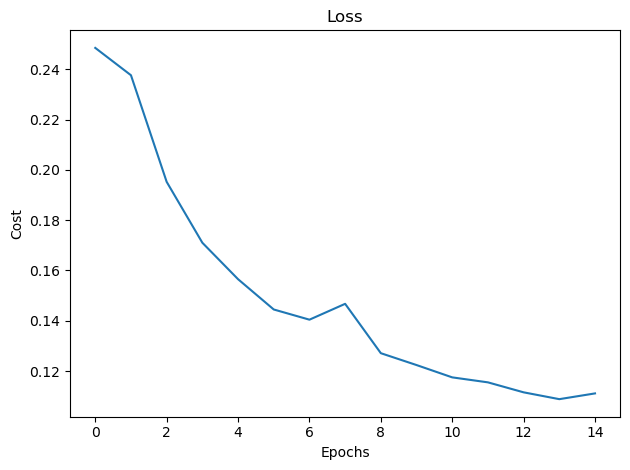

```python
# Variables for determining the loss over epochs
epochs = rnnB_history.epoch
loss = rnnB_history.history["loss"]

# Plots the loss graph
plt.plot(epochs, loss)
plt.ylabel("Cost")
plt.xlabel("Epochs")
plt.title("Loss")

plt.tight_layout()

plt.show()
```

The code below evaluates and visualizes the Receiver Operating Characteristic (ROC) curve and Area Under the Curve (AUC) for RNNB. The ROC curve is a graphical representation of the performance of a binary classification system, showing the trade-off between the true positive rate (TPR) and the false positive rate (FPR) as the decision threshold for classification is varied. The AUC is a metric that summarizes the overall performance of the model, with a higher AUC indicating better performance.

Our AUC for this run is 0.84 indicating that the model has a good ability to distinguish between positive and negative cases. The ROC curve visualizes this by showing a rise in the curve until reaching a point where the TPR is 0.83 and the FPR is 0.17. From there, it gradually increases until reaching the end of the graph indicating that the model is able to identify some positive cases while making few false positive predictions. Overall, this suggests that the RNN model is able to make correct predictions will small room for improvement.

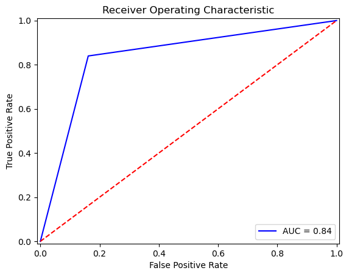

```python
# Variables for determining the ROC/AUC
fpr, tpr, threshold = roc_curve(
    np.argmax(y_test_ohe, axis=1), np.argmax(y_predict_proba, axis=1)
)
roc_auc = auc(fpr, tpr)

# Plots the ROC and AUC graph
plt.title("Receiver Operating Characteristic")
plt.plot(fpr, tpr, "b", label="AUC = %0.2f" % roc_auc)
plt.legend(loc="lower right")
plt.plot([0, 1], [0, 1], "r--")
plt.xlim([-0.01, 1.01])
plt.ylim([-0.01, 1.01])
plt.ylabel("True Positive Rate")
plt.xlabel("False Positive Rate")
plt.show()
```

The code below plots the training versus testing graph for RNNB. The graph has three subplots: the first subplot shows the training and validation loss versus epochs, the second subplot shows the training and validation recall versus epochs, and the third subplot shows the training and validation AUC versus epochs.

The training versus testing graph is used to visualize the performance of the model during training. We can see that the training loss and validation loss decrease as the number of epochs increases. The curves intersect each other at 3 points, and the validation curve rises from epoch 5 to 6, but continues decreases until the end where it ends up with a higher loss value than the training curve. Overall, the graph shows that the model is learning and improving.

The training recall and validation recall also increase as the number of epochs increases, thought they show erratic behavior. The curves overcome the other curve at multiple points, but the training curve comes out with a higher recall score by a small margin. Regardless, the graph demostrates that the model is becoming better at identifying the sentiment of reviews.

Finally, the training AUC and validation AUC increase as the number of epochs increases. Though the training curve has a higher AUC value by a slight margin, the graph indicates that the model is becoming better at distinguishing between positive and negative sentiment in reviews.

Overall, the graph shows that the RNN model is improving over time, and that it is performing well on both the training and validation sets.

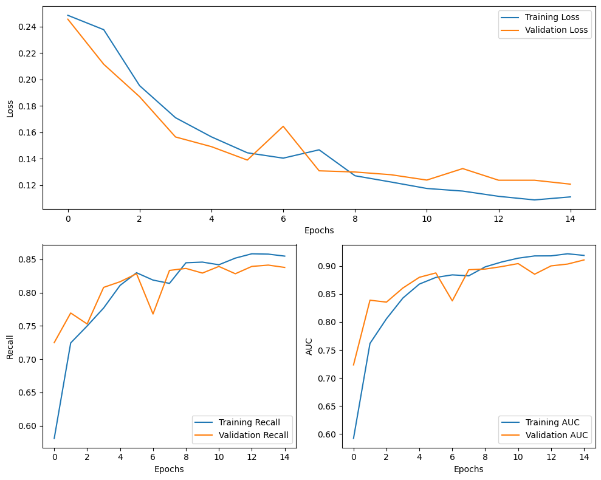

```python
# Model history values
hist_values = list(rnnB_history.history.values())

# Variables for plotting the training versus testing
train_loss   = hist_values[0]
train_recall = hist_values[1]
train_auc    = hist_values[2]
val_loss     = hist_values[3]
val_recall   = hist_values[4]
val_auc      = hist_values[5]

# Plots the training versus testing graph
plt.figure(figsize=(10, 8))
plt.subplot(2, 2, (1, 2))
plt.plot(train_loss, label="Training Loss")
plt.plot(val_loss, label="Validation Loss")
plt.xlabel("Epochs")
plt.ylabel("Loss")
plt.legend()

plt.subplot(2, 2, 3)
plt.plot(train_recall, label="Training Recall")
plt.plot(val_recall, label="Validation Recall")
plt.xlabel("Epochs")
plt.ylabel("Recall")
plt.legend()

plt.subplot(2, 2, 4)
plt.plot(train_auc, label="Training AUC")
plt.plot(val_auc, label="Validation AUC")
plt.xlabel("Epochs")
plt.ylabel("AUC")
plt.legend()

plt.tight_layout()

plt.show()
```

In this run, RNNB predicted 841 Negative sentiments and 841 Positive sentiments correctly, while mispredicting 155 and 163 Negative and Positive sentiments respectively. The model does not any bias towards any class 1, as the margin between the number of false positives and negatives is very small, similar to RNN1 and RNN5.

Accuracy is a measure of the overall correctness of a model's predictions, calculated as the ratio of the number of correct predictions to the total number of predictions. For this run, our initial accuracy score is 0.84 or roughly 84%.

Precision is a measure of how well a model correctly identifies positive instances among the predicted positive instances. Precision is calculated as the ratio of the number of true positive predictions to the total number of positive predictions (which would be the true positive predictions plus the false positive predictions). In our case, the precision score is 0.84 or 84%. It is the same as our accuracy value which we feel is ideal for finding a viable solution for field-use as it is important to minimize false positives and maximize true positives.

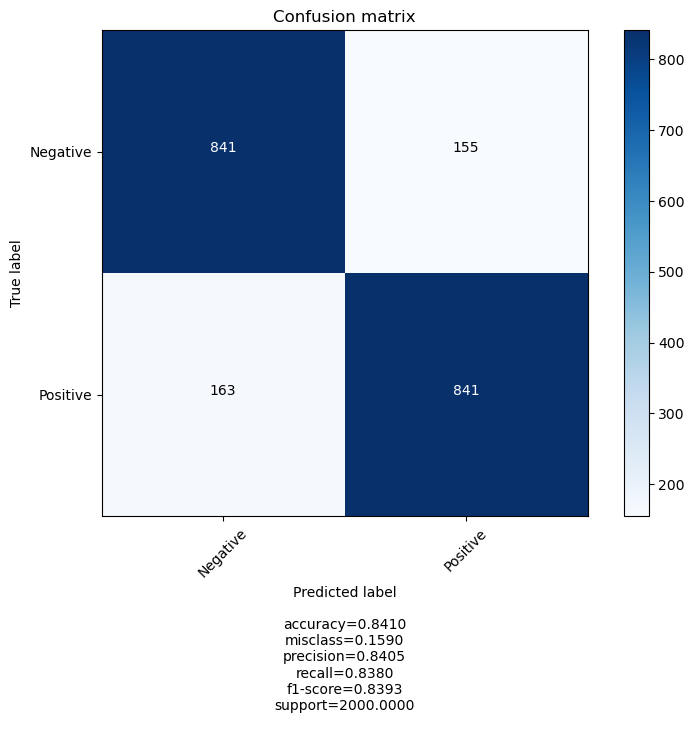

```python
class_report = classification_report(
    y_test_ohe, y_predict, zero_division=0, output_dict=True
)

plot_confusion_matrix(
    confusion_matrix(
        np.argmax(y_test_ohe, axis=1), np.argmax(y_predict, axis=1)
    ),
    [classes[0], classes[1]],
    normalize=False,
    class_results=class_report["weighted avg"],
)
```

### Model Comparisons with ConceptNet Model (RNNB)

The code below outputs a bar chart of each model's accuracy for comparison.

Out of our six models, RNNB performs the best, followed by RNN1 and RNN5, RNN3, RNN4, and finally RNN2.  
RNNB, which implements the ConceptNet network, outperforms our previously best models (RNN1 and RNN5), which implemented the LSTM architecture. A reason for this improvement could be due to further reducing the batch size to 128 instead of 256, which can help the model generalize better. Another reason could be due to the embedding model producing an output size of (None, 300) instead of (None, 200). The bigger output size for the model to handle more data throughout the layers, which in turn increases its performance.

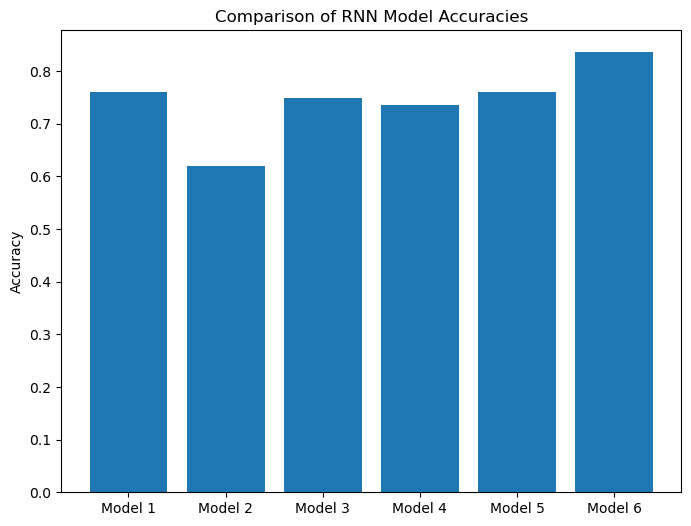

```python
accuracies = [acc_1, acc_2, acc_3, acc_4, acc_5, acc_6]

fig = plt.figure(figsize=[8, 6])
plt.bar([1, 2, 3, 4, 5, 6], accuracies)
plt.xticks([1, 2, 3, 4, 5, 6], [f"model {i}".title() for i in range(1, 7)])
plt.ylabel("Accuracy")
plt.title("Comparison of RNN Model Accuracies")
plt.show()
```

Below, we make a prediction using RNNB on a randomly selected review from the dataset df. The review text and the actual label are displayed, followed by the predicted label.

In this case, both the actual and predicted label are negative - meaning that the model correctly predicted the sentiment for this sample review.

```python
# Observe how the model predicts a review
review_test(rnnB, random.randint(1, 10000), df)
```

**Text:** this movie way long i lost interest one hour story saratoga trunk story child prominent new orleans man mistress after mother paris comes back new orleans scandalize legitimate family blackmail she gary cooper likewise seeking revenge railroad father land texas she movie saratoga resort long boring worth watching cooper fan the midget cupidon bright spot story

**Actual:** negative

```
1/1 - 1s - 761ms/epoch - 761ms/step
```

**Predicted:** negative